# 606_Week4_Assignment

SantoshCheruku

March 16, 2019

4.4 Heights of adults. Researchers studying anthropometry collected body girth measurements and skeletal diameter measurements, as well as age, weight, height and gender, for 507 physically active individuals. The histogram below shows the sample distribution of heights in centimeters. Min 147.2 Q1 163.8 Median 170.3 Mean 171.1 SD 9.4 Q3 177.8 Max 198.1

1. What is the point estimate for the average height of active individuals? What about the median?  
   **Mean is the point of estimate for the sample i.e., 171.1 and Median is the 170.3**
2. What is the point estimate for the standard deviation of the heights of active individuals? What about the IQR?  
   **9.4 is the standard deviation of the heights of activte individuals and IQR is Q3 - Q1 = 177.8 - 163.8 = 14**
3. Is a person who is 1m 80cm (180 cm) tall considered unusually tall? And is a person who is 1m 55cm (155cm) considered unusually short? Explain your reasoning.

   SE = SD / sqrt(N) = 9.4 / sqrt(507) = 9.4/22.52 = .417 p1 <- 171.1 + 1.96*.417 and p2<- 170.2827 Both 180 cm and 155 cm are unusual since they fall out of 95% range.
4. The researchers take another random sample of physically active individuals. Would you expect the mean and the standard deviation of this new sample to be the ones given above? Explain your reasoning.

**No, I do not expect the next sample to be similar. Since the target population if quite huge, a sample population (though high number), cannot be expected to be exactly similar to earlier sample.**

5. The sample means obtained are point estimates for the mean height of all active individuals, if the sample of individuals is equivalent to a simple random sample. What measure do we use to quantify the variability of such an estimate (Hint: recall that SD¯x = ! pn )? Compute this quantity using the data from the original sample under the condition that the data are a simple random sample.

4.14 Thanksgiving spending, Part I. The 2009 holiday retail season, which kicked o??? on November 27, 2009 (the day after Thanksgiving), had been marked by somewhat lower self-reported consumer spending than was seen during the comparable period in 2008. To get an estimate of consumer spending, 436 randomly sampled American adults were surveyed. Daily consumer spending for the six-day period after Thanksgiving, spanning the Black Friday weekend and Cyber Monday, averaged $84.71. A 95% confidence interval based on this sample is ($80.31, $89.11). Determine whether the following statements are true or false, and explain your reasoning.

1. We are 95% confident that the average spending of these 436 American adults is between $80.31 and $89.11. **False, the average spending calculated refers to entire population on average, not just sample.**
2. This confidence interval is not valid since the distribution of spending in the sample is right skewed. **False, the Confidence Interval can be considered valid, since the distribution is NOT heavily skewed and sample size it quite high (436) and the events are independent.**
3. 95% of random samples have a sample mean between $80.31 and $89.11. **That is True. Confidence Interval of 95% confirms that.**
4. We are 95% confident that the average spending of all American adults is between $80.31 and $89.11. **That is True. As per the confidence interval statement.**
5. A 90% confidence interval would be narrower than the 95% confidence interval since we don’t need to be as sure about our estimate. **That is True. As the confidence interval reduces, the interval of data also becomes narrower.**
6. In order to decrease the margin of error of a 95% confidence interval to a third of what it is now, we would need to use a sample 3 times larger. **No, We would need atleast nine times the size, since we calculate a sqrt of the count.**
7. The margin of error is 4.4. **True. Margin of Error = (89.11 - 80.31)/2**

4.24 Gifted children, Part I. Researchers investigating characteristics of gifted children collected data from schools in a large city on a random sample of thirty-six children who were identified as gifted children soon after they reached the age of four. The following histogram shows the distribution of the ages (in months) at which these children first counted to 10 successfully. Also provided are some sample statistics n 36 min 21 mean 30.69 sd 4.31 max 39

   HNull = 32 HAlt <32 significanceLevel - 0.10

**As per below data, we have to reject the null hypothesis since p value is less than significance level (.10)**

```r
mean <- 30.69
sd <- 4.31
n <- 36
se <- sd/sqrt(n)
z <- (mean - 32)/se
pVal <- pnorm(z)
pVal
```

```
## [1] 0.0341013
```

3. Interpret the p-value in context of the hypothesis test and the data.

**The pvalue was calculated as .034**

4. Calculate a 90% confidence interval for the average age at which gifted children first count to 10 successfully.

```r
z <- qnorm(.1)
lower <- mean - z*se
higher <- mean + z*se
lower
```

```
## [1] 31.61058
```

```r
higher
```

```
## [1] 29.76942
```

5. Do your results from the hypothesis test and the confidence interval agree? Explain. **Yes, they agree since both reject 32 value.**

4.26 Gifted children, Part II. Exercise 4.24 describes a study on gifted children. In this study, along with variables on the children, the researchers also collected data on the mother’s and father’s IQ of the 36 randomly sampled gifted children. The histogram below shows the distribution of mother’s IQ. Also provided are some sample statistics. n 36 min 101 mean 118.2 sd 6.5 max 131

1. Perform a hypothesis test to evaluate if these data provide convincing evidence that the average IQ of mothers of gifted children is di???erent than the average IQ for the population at large, which is 100. Use a significance level of 0.10. HNull <- 100 HAlt > 100 **P value for z =16 is much less than significance level. Hence we can say that avg IQ of mothers of gifted children is different from avg population**

```r
  meanIQ <- 118.2
  se <- 6.5/sqrt(36)
  z <-(118.2-100) / se
  #P value for z =16 is much less than significance level
```

```
(b) Calculate a 90% confidence interval for the average IQ of mothers of gifted children.
```

```r
z <- qnorm(.1)
lower <- meanIQ - z*se
upper <- meanIQ + z*se
lower
```

```
## [1] 119.5883
```

```r
upper
```

```
## [1] 116.8117
```

```
(c) Do your results from the hypothesis test and the confidence interval agree? Explain.
```

** Yes the 90% CI is above IQ value of 100**

4.34 CLT. Define the term “sampling distribution” of the mean, and describe how the shape, center, and spread of the sampling distribution of the mean change as sample size increases.

Answer:

[output not shown]

4.40 CFLBs. A manufacturer of compact fluorescent light bulbs advertises that the distribution of the lifespans of these light bulbs is nearly normal with a mean of 9,000 hours and a standard deviation of 1,000 hours. (a) What is the probability that a randomly chosen light bulb lasts more than 10,500 hours?

```r
mean <- 9000
sd <- 1000
z <- (10500 - mean) / sd
p <- 1 - pnorm(z)
p
```

```
## [1] 0.0668072
```

2. Describe the distribution of the mean lifespan of 15 light bulbs.
3. What is the probability that the mean lifespan of 15 randomly chosen light bulbs is more than 10,500 hours?

** Per below, the probability is 0**

```r
mean <- 10500
n<-15
se <- sd/sqrt(n)
z <- (10500- 9000) / se
z
```

```
## [1] 5.809475
```

```r
1 - pnorm(z) #Upper tail
```

```
## [1] 3.133452e-09
```

4. Sketch the two distributions (population and sampling) on the same scale.

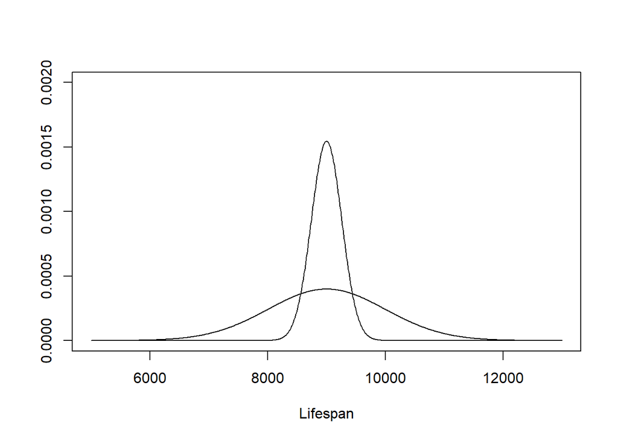

```r
mean <- 9000

s <- seq(5000,13000,10)
plot(s, dnorm(s,9000, 1000), type="l", ylim = c(0,0.002), xlab = "Lifespan", ylab="")
lines(s, dnorm(s,9000, se))
```

5. Could you estimate the probabilities from parts (a) and (c) if the lifespans of light bulbs had a skewed distribution?

   **No, since sample populations are pretty low, we cannot assume the probabilities if they had a skewed distribution**

4.48 Same observation, di???erent sample size. Suppose you conduct a hypothesis test based on a sample where the sample size is n = 50, and arrive at a p-value of 0.08. You then refer back to your notes and discover that you made a careless mistake, the sample size should have been n = 500. Will your p-value increase, decrease, or stay the same? Explain.

** Since if sample size increases, it decreases the SE value. Decrease in SE value increases the Z value, resulting in a reduced P value.**